[GitHub](https://github.com/JuliaGeometry/DelaunayTriangulation.jl)[](https://github.com/JuliaGeometry/DelaunayTriangulation.jl/tree/main/docs/src/literate_tutorials/constrained_outer_boundary.jl)

# Constrained Triangulations

## Outer Boundary

This tutorial now considers the case where, rather than only having constrained segments, we have a constrained outer boundary. This is especially useful as it allows us to, for example, have a non-convex boundary. To start, let us load in the packages we will need.

```julia
using DelaunayTriangulation
using CairoMakie
```

Now, we define some of the points we will be triangulating.

```julia
pts = [
    (-7.36, 12.55), (-9.32, 8.59), (-9.0, 3.0), (-6.32, -0.27),
    (-4.78, -1.53), (2.78, -1.41), (-5.42, 1.45), (7.86, 0.67),
    (10.92, 0.23), (9.9, 7.39), (8.14, 4.77), (13.4, 8.61),
    (7.4, 12.27), (2.2, 13.85), (-3.48, 10.21), (-4.56, 7.35),
    (3.44, 8.99), (3.74, 5.87), (-2.0, 8.0), (-2.52, 4.81),
    (1.34, 6.77), (1.24, 4.15)
]
```

```
22-element Vector{Tuple{Float64, Float64}}:
 (-7.36, 12.55)
 (-9.32, 8.59)
 (-9.0, 3.0)
 (-6.32, -0.27)
 (-4.78, -1.53)
 (2.78, -1.41)
 (-5.42, 1.45)
 (7.86, 0.67)
 (10.92, 0.23)
 (9.9, 7.39)
 (8.14, 4.77)
 (13.4, 8.61)
 (7.4, 12.27)
 (2.2, 13.85)
 (-3.48, 10.21)
 (-4.56, 7.35)
 (3.44, 8.99)
 (3.74, 5.87)
 (-2.0, 8.0)
 (-2.52, 4.81)
 (1.34, 6.77)
 (1.24, 4.15)
```

To define a boundary, we need to provide a counter-clockwise sequence of indices corresponding to the boundary points, and the first index must match the last index so the boundary is closed. While we could include in `pts` the boundary points that we want to include, and then write down the indices of the points within `pts`, this is cumbersome and often tedious to get correct. So, we instead provide the function `convert_boundary_points_to_indices` which takes in a vector of coordinates, and then returns the correct set of indices. Here is how we use it:

```julia
boundary_points = [
    (0.0, 0.0), (2.0, 1.0), (3.98, 2.85), (6.0, 5.0),
    (7.0, 7.0), (7.0, 9.0), (6.0, 11.0), (4.0, 12.0),
    (2.0, 12.0), (1.0, 11.0), (0.0, 9.13), (-1.0, 11.0),
    (-2.0, 12.0), (-4.0, 12.0), (-6.0, 11.0), (-7.0, 9.0),
    (-6.94, 7.13), (-6.0, 5.0), (-4.0, 3.0), (-2.0, 1.0), (0.0, 0.0)
]
boundary_nodes, pts = convert_boundary_points_to_indices(boundary_points; existing_points=pts);
```

The keyword argument `existing_points` is so that the points in `boundary_points` get appended (in-place) to `pts`, as we see:

```julia
pts
```

```
42-element Vector{Tuple{Float64, Float64}}:
 (-7.36, 12.55)
 (-9.32, 8.59)
 (-9.0, 3.0)
 (-6.32, -0.27)
 (-4.78, -1.53)
 (2.78, -1.41)
 (-5.42, 1.45)
 (7.86, 0.67)
 (10.92, 0.23)
 (9.9, 7.39)
 (8.14, 4.77)
 (13.4, 8.61)
 (7.4, 12.27)
 (2.2, 13.85)
 (-3.48, 10.21)
 (-4.56, 7.35)
 (3.44, 8.99)
 (3.74, 5.87)
 (-2.0, 8.0)
 (-2.52, 4.81)
 (1.34, 6.77)
 (1.24, 4.15)
 (0.0, 0.0)
 (2.0, 1.0)
 (3.98, 2.85)
 (6.0, 5.0)
 (7.0, 7.0)
 (7.0, 9.0)
 (6.0, 11.0)
 (4.0, 12.0)
 (2.0, 12.0)
 (1.0, 11.0)
 (0.0, 9.13)
 (-1.0, 11.0)
 (-2.0, 12.0)
 (-4.0, 12.0)
 (-6.0, 11.0)
 (-7.0, 9.0)
 (-6.94, 7.13)
 (-6.0, 5.0)
 (-4.0, 3.0)
 (-2.0, 1.0)
```

The `boundary_nodes` is then these indices:

```julia
boundary_nodes
```

```
21-element Vector{Int64}:
 23
 24
 25
 26
 27
 28
 29
 30
 31
 32
 33
 34
 35
 36
 37
 38
 39
 40
 41
 42
 23
```

To now triangulate, we use the `boundary_nodes` keyword argument. Like in the last tutorial, we also give a comparison to the unconstrained version.

```julia
tri = triangulate(pts)
cons_tri = triangulate(pts; boundary_nodes)
```

```
Delaunay Triangulation.
   Number of vertices: 28
   Number of triangles: 34
   Number of edges: 61
   Has boundary nodes: true
   Has ghost triangles: true
   Curve-bounded: false
   Weighted: false
   Constrained: true
```

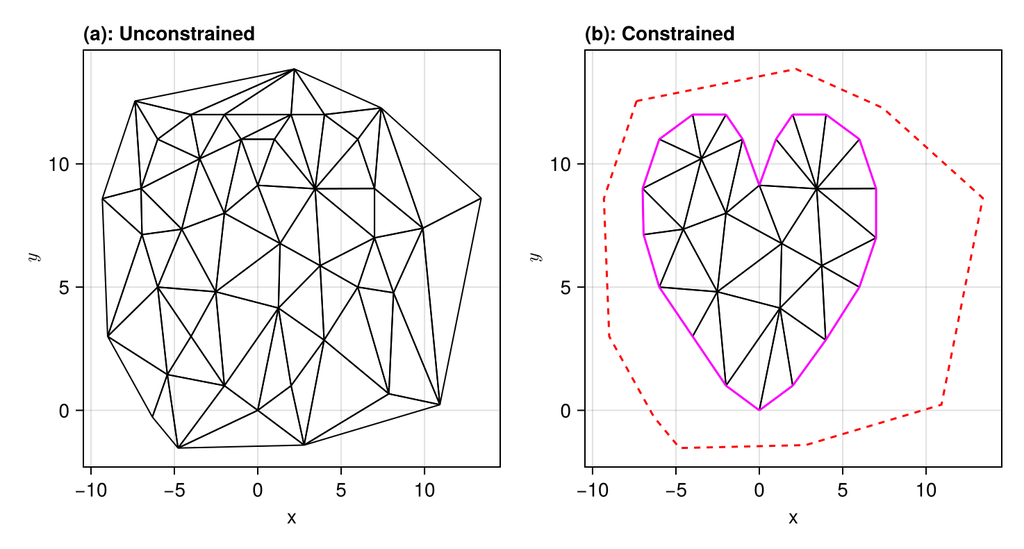

```julia
fig = Figure()
ax1 = Axis(fig[1, 1], xlabel="x", ylabel=L"y",
    title="(a): Unconstrained", titlealign=:left,
    width=300, height=300)
ax2 = Axis(fig[1, 2], xlabel="x", ylabel=L"y",
    title="(b): Constrained", titlealign=:left,
    width=300, height=300)
triplot!(ax1, tri)
triplot!(ax2, cons_tri, show_constrained_edges=true, show_convex_hull=true)
resize_to_layout!(fig)
fig
```

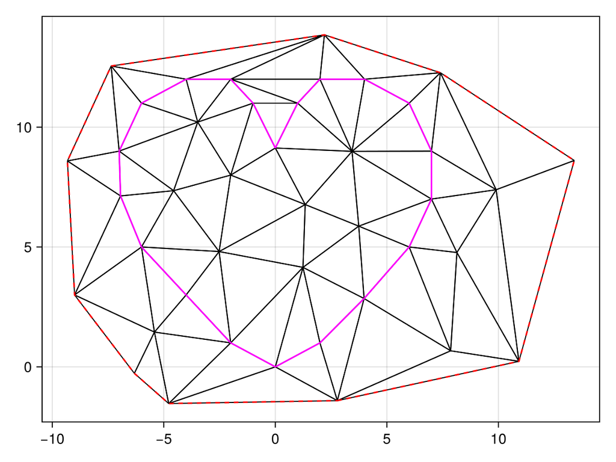

```julia
full_tri = triangulate(pts; boundary_nodes, delete_holes=false)
fig, ax, sc = triplot(full_tri, show_constrained_edges=true, show_convex_hull=true)
```

This default behaviour does mean you need to be careful if you use `DelaunayTriangulation.each_point` or `DelaunayTriangulation.each_point_index`, as these iterators will contain all points, possibly iterating over points that aren't in the triangulation. For this reason, it is recommended that you use `each_solid_vertex` as a default.

There are multiple methods available for working directly with the boundary nodes. You can get the boundary nodes using `get_boundary_nodes(tri)`:

```julia
get_boundary_nodes(cons_tri)
```

```
21-element Vector{Int64}:
 23
 24
 25
 26
 27
 28
 29
 30
 31
 32
 33
 34
 35
 36
 37
 38
 39
 40
 41
 42
 23
```

\[A = \dfrac{1}{2}\sum_{i=1}^n \left(y_i + y_{i+1}\right)\left(x_i - x_{i+1}\right).\]

Here is one implementation.

```julia
function shoelace_area(tri)
    bn = get_boundary_nodes(tri)
    n = num_boundary_edges(bn) # length(bn) - 1 in this case since bn[1] = bn[end]
    A = 0.0
    for i in 1:n
        vᵢ = get_boundary_nodes(bn, i)
        vᵢ₊₁ = get_boundary_nodes(bn, i+1)
        pᵢ, pᵢ₊₁ = get_point(tri, vᵢ, vᵢ₊₁)
        xᵢ, yᵢ = getxy(pᵢ)
        xᵢ₊₁, yᵢ₊₁ = getxy(pᵢ₊₁)
        A += (yᵢ + yᵢ₊₁)*(xᵢ - xᵢ₊₁)
    end
    return A/2
end
shoelace_area(cons_tri)
```

```
119.20499999999998
```

We also provide a map that contains the edges as the keys (*not* in order), and the values are `Tuple`s `(I, J)` such that `get_boundary_nodes(get_boundary_nodes(cons_tri, I), J)` gives the corresponding edge. The first call, `bn = get_boundary_nodes(cons_tri, I)` is for obtaining the chain of boundary edges containing the boundary edge, and then `get_boundary_nodes(bn, j)` gets the actual edge.

```julia
get_boundary_edge_map(cons_tri)
```

```
Dict{Tuple{Int64, Int64}, Tuple{Vector{Int64}, Int64}} with 20 entries:
  (23, 24) => ([23, 24, 25, 26, 27, 28, 29, 30, 31, 32, 33, 34, 35, 36, 37, 38, 39, 40, 41, 42, 23], 1)
  (40, 41) => ([23, 24, 25, 26, 27, 28, 29, 30, 31, 32, 33, 34, 35, 36, 37, 38, 39, 40, 41, 42, 23], 18)
  (25, 26) => ([23, 24, 25, 26, 27, 28, 29, 30, 31, 32, 33, 34, 35, 36, 37, 38, 39, 40, 41, 42, 23], 3)
  (35, 36) => ([23, 24, 25, 26, 27, 28, 29, 30, 31, 32, 33, 34, 35, 36, 37, 38, 39, 40, 41, 42, 23], 13)
  (30, 31) => ([23, 24, 25, 26, 27, 28, 29, 30, 31, 32, 33, 34, 35, 36, 37, 38, 39, 40, 41, 42, 23], 8)
  (29, 30) => ([23, 24, 25, 26, 27, 28, 29, 30, 31, 32, 33, 34, 35, 36, 37, 38, 39, 40, 41, 42, 23], 7)
  (42, 23) => ([23, 24, 25, 26, 27, 28, 29, 30, 31, 32, 33, 34, 35, 36, 37, 38, 39, 40, 41, 42, 23], 20)
  (33, 34) => ([23, 24, 25, 26, 27, 28, 29, 30, 31, 32, 33, 34, 35, 36, 37, 38, 39, 40, 41, 42, 23], 11)
  (38, 39) => ([23, 24, 25, 26, 27, 28, 29, 30, 31, 32, 33, 34, 35, 36, 37, 38, 39, 40, 41, 42, 23], 16)
  (27, 28) => ([23, 24, 25, 26, 27, 28, 29, 30, 31, 32, 33, 34, 35, 36, 37, 38, 39, 40, 41, 42, 23], 5)
  (26, 27) => ([23, 24, 25, 26, 27, 28, 29, 30, 31, 32, 33, 34, 35, 36, 37, 38, 39, 40, 41, 42, 23], 4)
  (39, 40) => ([23, 24, 25, 26, 27, 28, 29, 30, 31, 32, 33, 34, 35, 36, 37, 38, 39, 40, 41, 42, 23], 17)
  (24, 25) => ([23, 24, 25, 26, 27, 28, 29, 30, 31, 32, 33, 34, 35, 36, 37, 38, 39, 40, 41, 42, 23], 2)
  (28, 29) => ([23, 24, 25, 26, 27, 28, 29, 30, 31, 32, 33, 34, 35, 36, 37, 38, 39, 40, 41, 42, 23], 6)
  (41, 42) => ([23, 24, 25, 26, 27, 28, 29, 30, 31, 32, 33, 34, 35, 36, 37, 38, 39, 40, 41, 42, 23], 19)
  (31, 32) => ([23, 24, 25, 26, 27, 28, 29, 30, 31, 32, 33, 34, 35, 36, 37, 38, 39, 40, 41, 42, 23], 9)
  (32, 33) => ([23, 24, 25, 26, 27, 28, 29, 30, 31, 32, 33, 34, 35, 36, 37, 38, 39, 40, 41, 42, 23], 10)
  (34, 35) => ([23, 24, 25, 26, 27, 28, 29, 30, 31, 32, 33, 34, 35, 36, 37, 38, 39, 40, 41, 42, 23], 12)
  (37, 38) => ([23, 24, 25, 26, 27, 28, 29, 30, 31, 32, 33, 34, 35, 36, 37, 38, 39, 40, 41, 42, 23], 15)
  (36, 37) => ([23, 24, 25, 26, 27, 28, 29, 30, 31, 32, 33, 34, 35, 36, 37, 38, 39, 40, 41, 42, 23], 14)
```

In our case, the `I` is just `boundary_nodes` since we only have one contiguous boundary. To give an example, take

```julia
bem = get_boundary_edge_map(cons_tri)
e, (I, J) = first(bem)
```

```
(23, 24) => ([23, 24, 25, 26, 27, 28, 29, 30, 31, 32, 33, 34, 35, 36, 37, 38, 39, 40, 41, 42, 23], 1)
```

```julia
bn = get_boundary_nodes(cons_tri, I) # same as boundary_nodes for this problem; see the later tutorials
bn_j = get_boundary_nodes(bn, J)
```

```
23
```

This returns `23`, which is the start of the edge `e`. The full edge is given by

```julia
get_boundary_nodes.(Ref(bn), (J, J+1)) # Ref to not broadcast over bn
```

```
(23, 24)
```

To give an example, here's how we compute the perimeter of the triangulation. This only needs the edges, so we only consider the `keys` of the map.

```julia
function get_perimeter(tri)
    bem = get_boundary_edge_map(tri)
    ℓ = 0.0
    for e in keys(bem)
        u, v = edge_vertices(e)
        p, q = get_point(tri, u, v)
        ℓ += sqrt((getx(p) - getx(q))^2 + (gety(p) - gety(q))^2)
    end
    return ℓ
end
get_perimeter(cons_tri)
```

```
44.23794172896859
```

## Just the code

An uncommented version of this example is given below. You can view the source code for this file [here](https://github.com/JuliaGeometry/DelaunayTriangulation.jl/tree/main/docs/src/literate_tutorials/constrained_outer_boundary.jl).

```julia
using DelaunayTriangulation
using CairoMakie

pts = [
    (-7.36, 12.55), (-9.32, 8.59), (-9.0, 3.0), (-6.32, -0.27),
    (-4.78, -1.53), (2.78, -1.41), (-5.42, 1.45), (7.86, 0.67),
    (10.92, 0.23), (9.9, 7.39), (8.14, 4.77), (13.4, 8.61),
    (7.4, 12.27), (2.2, 13.85), (-3.48, 10.21), (-4.56, 7.35),
    (3.44, 8.99), (3.74, 5.87), (-2.0, 8.0), (-2.52, 4.81),
    (1.34, 6.77), (1.24, 4.15)
]

boundary_points = [
    (0.0, 0.0), (2.0, 1.0), (3.98, 2.85), (6.0, 5.0),
    (7.0, 7.0), (7.0, 9.0), (6.0, 11.0), (4.0, 12.0),
    (2.0, 12.0), (1.0, 11.0), (0.0, 9.13), (-1.0, 11.0),
    (-2.0, 12.0), (-4.0, 12.0), (-6.0, 11.0), (-7.0, 9.0),
    (-6.94, 7.13), (-6.0, 5.0), (-4.0, 3.0), (-2.0, 1.0), (0.0, 0.0)
]
boundary_nodes, pts = convert_boundary_points_to_indices(boundary_points; existing_points=pts);

pts

boundary_nodes

tri = triangulate(pts)
cons_tri = triangulate(pts; boundary_nodes)

fig = Figure()
ax1 = Axis(fig[1, 1], xlabel="x", ylabel=L"y",
    title="(a): Unconstrained", titlealign=:left,
    width=300, height=300)
ax2 = Axis(fig[1, 2], xlabel="x", ylabel=L"y",
    title="(b): Constrained", titlealign=:left,
    width=300, height=300)
triplot!(ax1, tri)
triplot!(ax2, cons_tri, show_constrained_edges=true, show_convex_hull=true)
resize_to_layout!(fig)
fig

full_tri = triangulate(pts; boundary_nodes, delete_holes=false)
fig, ax, sc = triplot(full_tri, show_constrained_edges=true, show_convex_hull=true)

get_boundary_nodes(cons_tri)

function shoelace_area(tri)
    bn = get_boundary_nodes(tri)
    n = num_boundary_edges(bn) # length(bn) - 1 in this case since bn[1] = bn[end]
    A = 0.0
    for i in 1:n
        vᵢ = get_boundary_nodes(bn, i)
        vᵢ₊₁ = get_boundary_nodes(bn, i+1)
        pᵢ, pᵢ₊₁ = get_point(tri, vᵢ, vᵢ₊₁)
        xᵢ, yᵢ = getxy(pᵢ)
        xᵢ₊₁, yᵢ₊₁ = getxy(pᵢ₊₁)
        A += (yᵢ + yᵢ₊₁)*(xᵢ - xᵢ₊₁)
    end
    return A/2
end
shoelace_area(cons_tri)

get_boundary_edge_map(cons_tri)

bem = get_boundary_edge_map(cons_tri)
e, (I, J) = first(bem)

bn = get_boundary_nodes(cons_tri, I) # same as boundary_nodes for this problem; see the later tutorials
bn_j = get_boundary_nodes(bn, J)

get_boundary_nodes.(Ref(bn), (J, J+1)) # Ref to not broadcast over bn

function get_perimeter(tri)
    bem = get_boundary_edge_map(tri)
    ℓ = 0.0
    for e in keys(bem)
        u, v = edge_vertices(e)
        p, q = get_point(tri, u, v)
        ℓ += sqrt((getx(p) - getx(q))^2 + (gety(p) - gety(q))^2)
    end
    return ℓ
end
get_perimeter(cons_tri)
```

*This page was generated using Literate.jl.*